# Bgee RNA-Seq analysis pipeline

**General information:**

1. Introduction
2. Step 1: Data annotation
3. Step 2: Data download and preparation
4. Step 3: RNA-Seq library analyses
   1. Data preparation
   2. Pseudo-mapping to transcriptome with Kallisto
   3. Result processing
   4. Sanity checks
   5. TMM normalization, present/absent expression calls, expression ranks

**User tutorial:**

1. Notebook

**Developer guidelines**

1. Preparation steps
2. Mapping the libraries
3. Mapping the libraries: TODOs
4. Presence/absence calls
5. RNA-Seq insertion
6. Insert feature length
7. Calculation of TMM normalization factors
8. Back-up
9. Partial update of Bgee to add RNA-Seq data only

(Note that the developer guidelines include information about how we select valid sets of intergenic regions, allowing to estimate the background transcriptional noise in each library).

# General Information

## Introduction

RNA-Seq data are used to produce:

- baseline calls of presence/absence of expression
- ranking of these baseline calls to identify the most important conditions with expression, for each gene
- calls of differential over-/under-expression

These results are then integrated in a consistent manner with all other results from other data types, to produce global calls of presence/absence of expression, and to compute gene expression ranks for calls of presence/absence of expression.

You can check the most up-to-date versions of all parameters, software, and scripts used, directly in the Makefile of this pipeline step.

## Step 1: Data annotation

RNA-Seq data present in SRA are selected and annotated using information present in GEO, or in papers, or provided by the Model Organism Database WormBase.

## Step 2: Data download and preparation

Bgee annotations are parsed in order to retrieve the relevant information about SRA files to download, using the NCBI e-utils (for instance, SRR IDs of runs part of a library). Data annotated are downloaded from SRA using the NCBI SRA Toolkit and the Aspera software, and then converted to FASTQ files. For GTEx data, FASTQ files are downloaded through the dbGaP Authorized Access System using Aspera.

GTF annotation files and genome sequence fasta files are retrieved from Ensembl and Ensembl metazoa for all species included in Bgee. Check “data sources” to see the Ensembl version used for this release of Bgee. This information is used to identify sequences of genic regions, exonic regions, and intergenic regions. It is also used to generate indexed transcriptome files for all species in Bgee, using the TopHat and Kallisto software.

## Step 3: RNA-Seq library analyses

For each library:

### Data preparation:

- For each run, check for presence of single-end FASTQ read file, or of the two FASTQ files for paired-end runs.
- For each run, estimation of read length, to make sure the information provided in SRA is correct, and for checking that the reads are not too short for Kallisto indexing with default k-mer length. This is done by extracting the first read/read pair from the FASTQ file. Note that this can potentially provide incorrect information if all reads do not have the same length (for instance, if some reads were trimmed).
- If the reads are too short for Kallisto indexing with default k-mer length, the k-mer length is set to 15 nucleotides. Otherwise, use of the default Kallisto k-mer length (you can also check the most up-to-date value of this parameter directly in the Makefile of this pipeline step).
- A FastQC file is generated for each FASTQ file, to check for potential problems.

### Pseudo-mapping to transcriptome with Kallisto

The following parameters are used (you can check the most up-to-date values of these parameters directly in the Makefile of this pipeline step):

### Result processing:

- From the Kallisto output, for each genomic feature, counts of pseudo-aligned reads are retrieved.
- We sum at the gene level the counts of pseudo-aligned reads computed at the transcript level by Kallisto.
- The pseudo-aligned read counts, and the genomic feature effective lengths, are used to compute TPM and FPKM values. The values provided in Bgee are computed on the basis of genic regions only, but we also compute this information considering other genomic features, for sanity checks, and for calling genes as present/absent (see post-processing below).

### Sanity checks:

We check for each library:

- The FastQC file produced
- The density plot of TPM values for various groups of genomic features (protein-coding genes, intergenic regions, etc)
- Sum of counts of pseudo-aligned reads, assigned TPM values (for instance, presence of high number of “NA” in Kallisto output)

### Post-processing: normalization and generation of expression calls

#### TMM normalization

We compute TMM normalization factors to normalize in each experiment the FPKM and TPM values computed at the previous step. As we compute these values using genic regions only, the TMM factors are also computed by considering genic regions only. We compute the TMM factors using the Bioconductor package edgeR, for sets of samples from a same experiment, within one species, platform, library type and library orientation. We then check for the amplitude and distributions of TMM factors across experiments, to identify potentially aberrant values.

#### Generation of baseline calls of presence/absence of expression

To define the call of expression of a gene in a library as “present”, we check whether its level of expression is over the background transcriptional noise in this library. To estimate the background transcriptional noise in each library, we use the level of expression of a set of intergenic regions. How we define this set of intergenic regions is described below in this document, in the developer documentation section (see Presence/absence calls).

#### Expression rank computations

Gene expression ranks allow to identify the most functionally-relevant conditions related to the expression of a gene. It is computed from integrating all data types used in Bgee. See post_processing/ for this pipeline step.

# User tutorial

## Notebook

This notebook can be used to run the different steps of the RNA-Seq pipeline.

The scripts provided in this documentation can be runned directly in LSF servers.

To run in your local machine just remove all #BSUB and the referent module.

#### **Data**

The data provided by the user to run the full pipeline should be fastq files (lanes that belongs to the same sample should be merged into one fastq file, but this is not mandatory to run the pipeline).

#### **Reference files**

In order to run the pipeline 3 mandatory files should be present:

- Species.cdna.all.fa.gz
- Species.gtf.gz
- Species.dna.toplevel.fa

This files can be downloaded from the following source: https://ftp.ensemblgenomes.org/pub/ or https://ftp.ensembl.org/pub/ (for vertebrates)

#### **Create info files**

The Bgee pipeline runs based on a file describing each library, as shown below:

- rna_seq_sample_info –> a text input file that organize libraries (samples) per experiment.

In case you also discard some samples a file should also be provided, in this case with the referent libraries:

- rna_seq_sample_excluded –> a text input file that exclude libraries (samples) per experiment.

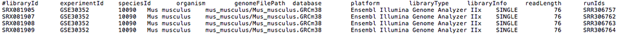

### **Important files to be generated**

In order to run the pipeline, 3 files are fundamental and need to be generated as a first step:

- gene2transcript –> file that links gene to transcripts mapping.
- gene2biotype –> a file that collects biotype for all genes.
- gtf_all –> a file that contains intergenic regions in the reference.

#### **Generate the files**

Generate **gene2transcript** and **gene2biotype** by using **prepareGTF.R**, the R script is present here 0Before/prepare_GTF.R.

From this script we are also able to retrive a **gtf_all** file that contains the exonic regions from all transcripts of each gene and the intergenic regions annotated.

```
#!/bin/bash
#BSUB -L /bin/bash
#BSUB -o out_prepareGTF
#BSUB -e error_prepareGTF
#BSUB -M 5000000
#BSUB -R "rusage[mem=5192]"
#BSUB -R "span[ptile=8]"
#BSUB -n 8
#BSUB -J prepareGTF
#BSUB -u user@email

## How to use:
## ./prepareGTF.sh @gene_gtf_path @output_gtf_name @new_output @input_file @script

module add R/3.5.1;
module add UHTS/Aligner/tophat/2.1.1;
module add UHTS/Analysis/kallisto/0.44.0;

gene_gtf_path=$1
output_gtf_name=$2
new_output=$3
input_file_genome_file=$4
script=$5

echo prepare gtf...
R CMD BATCH --no-save --no-restore "--args gene_gtf_path=\"$gene_gtf_path\" output_gtf_path=\"$output_gtf_name\"" $script
```

This new reference **gtf_all** is used to:

- Generate a modified transcriptome.fa file by using tophat,

```
echo generate new transcriptome...
gtf_to_fasta $new_output/Species.gtf_all $input_file_genome_file  $new_output/Species_transcriptome.fa

sed -E 's/>[0-9]* />/g' $new_output/Species_transcriptome.fa > $new_output/Species_transcriptome_final.fa
```

that a posteriori will be used to

- build a transcriptome index that later on is used by kallisto quant.

```
echo run kallisto index...

## we use by default kmer size = 31, if your read length are smaller please add -k followed by the kmer size that you intends to the command bellow
kallisto index -i $new_output/Species_transcripts.idx $new_output/Species_transcriptome_final.fa
```

**run the bash script on server directly:**

```
bsub -o out_prepareGTF -e error_prepareGTF -M 5000000 -R "rusage[mem=5192]" -J prepareGTF -u user@email -q normal "./prepareGTF.sh Species.gtf prepareGTF_output/Species prepareGTF_output/ Species.dna.toplevel.fa prepare_GTF.R"
```

### **Starting analysis per library**

#### **1) Control quality + Kallisto pseudo-alignment**

```
#!/bin/bash
#BSUB -L /bin/bash
#BSUB -o out_QC_Kall
#BSUB -e error_QC_Kall
#BSUB -M 20000000
#BSUB -R "rusage[mem=20192]"
#BSUB -R "span[ptile=8]"
#BSUB -n 8
#BSUB -J ControlQuality_Kallisto
#BSUB -u user@email

### This script run the control quality (FASTQC) + Kallisto (QUANT) per library
## How to use:
## ./QC_Kall.sh @library @index_file
## library --> Folder where we have all *.fastq.gz files per library referent to one experiment
## index_file --> Transcriptome index file to run Kallisto

module add UHTS/Quality_control/fastqc/0.11.7;
module add UHTS/Analysis/kallisto/0.44.0;

library=$1
index_file=$2

for i in `find $library -name *.fastq.gz`
do

## Extract name of the library and pathway...
file=$(basename $i)
file=${file%.fastq.gz}
DIR=$(dirname "${i}")

## Run fastqc and write the output directlly in same directory...
echo Running fastqc $file .....
## -exec gunzip -c  '{}' ';' |
fastqc  $i

## Run Kallisto per library and save in the same directory...
echo Running Kallisto $file .....

## note the example is done for single-end libraries
## if you use paired-end you should remove: --single -l 180 -s 20
## by default kallisto running mode is paired-end
kallisto quant -i $index_file -o $DIR --single -l 180 -s 20 $i --bias

done
```

**run the bash script on server directly:**

```
bsub -o out_QC_kall -e error_QC_kall -M 5000000 -R "rusage[mem=5192]" -J QC_Kall -u user@email -q normal "./QC_Kall.sh All_Data/ prepareGTF_output/Species_transcripts.idx"
```

#### **2) Run the analysis per library and sum over all libraries from the same species**

2.1) The script for the analysis is present in 1Run/rna_seq_analysis.R

2.2) The script for the sum across species is present in 1Run/rna_seq_sum_by_species.R

```
#!/bin/bash
#BSUB -L /bin/bash
#BSUB -o out_pipeline_1-2
#BSUB -e error_pipeline_1-2
#BSUB -M 20000000
#BSUB -R "rusage[mem=20192]"
#BSUB -R "span[ptile=8]"
#BSUB -n 8
#BSUB -J pipeline_1-2
#BSUB -u user@email

module add R/3.5.1;

## How to use:
## ./pipeline_1-2.sh @kallisto_count_folder @gene2transcript_file @gene2biotype_file \
## @rna_seq_sample_info @rna_seq_sample_excluded @DIR @script_analysis @script_sum

## kallisto_count_folder --> Folder experiment
## gene2transcript_file --> output file from prepare_gtf.r
## gene2biotype_file --> output file from prepare_gtf.r
## rna_seq_sample_info --> info about each library
## rna_seq_sample_excluded --> info about library excluded
## DIR --> where we should create a sum folder for the species
## script_analysis --> rna_seq_analysis.R
## script_sum --> rna_seq_sum_by_species.R

kallisto_count_folder=$1
gene2transcript_file=$2
gene2biotype_file=$3
rna_seq_sample_info=$4
rna_seq_sample_excluded=$5
DIR=$6
script_analysis=$7
script_sum=$8

mkdir $DIR/sum_by_species_folder

echo Start running the first script of the pipeline ...
## Per library
for folder in $kallisto_count_folder/*
do

R CMD BATCH --no-save --no-restore "--args  kallisto_count_folder=\"$folder\" \
gene2transcript_file=\"$gene2transcript_file\" gene2biotype_file=\"$gene2biotype_file\" \
library_id=\"$folder\"" $script_analysis $folder/library_id.Rout

done

echo Start running the second script of the pipeline ...

R CMD BATCH --no-save --no-restore "--args rna_seq_sample_info=\"$rna_seq_sample_info\" rna_seq_sample_excluded=\"$rna_seq_sample_excluded\" \
kallisto_count_folder=\"$kallisto_count_folder\" sum_by_species_folder=\"$DIR/sum_by_species_folder\"" $script_sum $DIR/sum_by_species_folder/sum_by_species.Rout
```

**run the bash script on server directly:**

[output not shown]

**Select gaussian distribution based on the plot:**

After the summing of the all libraries that belongs to the same species a file need to be filled manualy, *gaussian_choice_by_species_TO_FILL.txt*.

This file allow to specify the chosen deconvoluted gaussians to coding and intergenic regions, as demonstrated in the figure below.

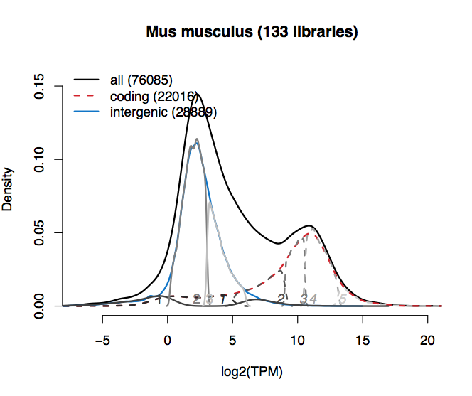

**Fill the gaussian_choice**

Example of gaussian file used to specify the selected distributions to coding and intergenic regions.

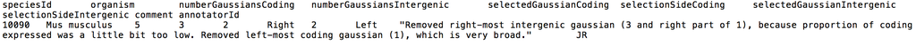

#### **3) Run the calls of present and absent genes per library**

3.1) The script to call present/absent genes is present in 1Run/rna_seq_presence_absence.R

```
#!/bin/bash
#BSUB -L /bin/bash
#BSUB -o out_pipeline_3
#BSUB -e error_pipeline_3
#BSUB -M 20000000
#BSUB -R "rusage[mem=20192]"
#BSUB -R "span[ptile=8]"
#BSUB -n 8
#BSUB -J pipeline_3
#BSUB -u user@email

module add R/3.5.1;

## How to use:
## ./pipeline_3.sh @rna_seq_sample_info @rna_seq_sample_excluded @kallisto_count_folder @sum_by_species_folder @gaussian_choice @out_folder @desired_r_cutoff @script_present_absent

## rna_seq_sample_info --> info about each library
## rna_seq_sample_excluded --> info about library excluded
## kallisto_count_folder --> Folder experiment
## sum_by_species_folder --> Folder where is the output of the sum
## gaussian_choice --> gaussian file
## out_folder --> output present and absent genes
## desired_r_cutoff --> desired cutoff value (proportion of intergenic, value between 0 and 1)
## R script

rna_seq_sample_info=$1
rna_seq_sample_excluded=$2
kallisto_count_folder=$3
sum_by_species_folder=$4
gaussian_choice=$5
out_folder=$6
desired_r_cutoff=$7
script_present_absent=$8

mkdir $out_folder/output_present_absent

echo running the last script of the pipeline: Call present and absent genes ...
## Per library

R CMD BATCH --no-save --no-restore "--args rna_seq_sample_info=\"$rna_seq_sample_info\" rna_seq_sample_excluded=\"$rna_seq_sample_excluded\" \
kallisto_count_folder=\"$kallisto_count_folder\" sum_by_species_folder=\"$sum_by_species_folder\" gaussian_choice=\"$gaussian_choice\" \
out_folder=\"$out_folder/output_present_absent\" desired_r_cutoff=\"$desired_r_cutoff\" plot_only=FALSE" $script_present_absent $out_folder/output_present_absent/rna_seq_presence_absence.Rout
```

**run the bash script on server directly:**

[output not shown]

### **General information about the output files**

After running the present/absent calls each library will contain 4 output files:

- abundance_gene_level+fpkm+intergenic+calls.tsv –> calls for genic and intergenic regions
- abundance_gene_level+new_tpm+new_fpkm+calls.tsv –> calls just for genic regions
- cutoff_info_file.tsv –> Descriptive file with cut-off information
- distribution_TPM_genic_intergenic+cutoff.pdf –> plot of the destribution for a particular library

Just looking in particular the calls output for one library:

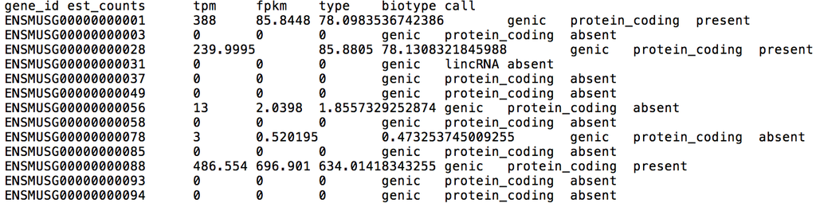

You will obtain also an output file that contain a boxplot for each different feature, as for example proportion of protein coding genes for each species across all libraries (if you are running just one species you will get just one boxplot per feature, as demonstrated in the boxplot below).

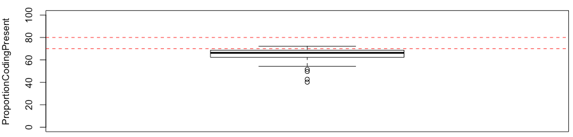

# Developer guidelines

1. Preparation steps
2. Mapping the libraries
3. Mapping the libraries: TODOs
4. Presence/absence calls
5. RNA-Seq insertion
6. Insert feature length
7. Calculation of TMM normalization factors
8. Back-up

## Preparation steps:

See README.md file in folder 0Before/ * If a FASTQ file is corrupted, it can be re-downloaded using get_SRA.pl script * **TODO**: add here command to re-download 1 library only

## Mapping the libraries:

- On Vital-IT, got to `/data/ul/dee/bgee/GIT/pipeline/RNA_Seq/`. Scripts are in folder 1Run/
- `git pull`
- `screen`
- `make run_pipeline`
- `Ctrl-a Ctrl-d` to exit the screen session, `screen -r` to come back
- Results are written in `$RNASEQ_CLUSTER_ALL_RES`. Beware that one month is passing fast! Please add to your calendar to do a touch of all files in less than a month.

```
find $RNASEQ_CLUSTER_ALL_RES/ -exec touch {} \;
```

- Checks during run:

```
 bjobs
 less /data/ul/dee/bgee/GIT/pipeline/RNA_Seq/run_pipeline.tmp
 # number of launched jobs
 grep -c 'is submitted to queue <bgee>' /data/ul/dee/bgee/GIT/pipeline/RNA_Seq/run_pipeline.tmp
 # result folder
 ll $RNASEQ_CLUSTER_ALL_RES
 # number of successful jobs
 ll $RNASEQ_CLUSTER_ALL_RES/*/DONE.txt | wc -l
 # list of unsuccessful jobs (have no DONE.txt and have a .out file)
 find $RNASEQ_CLUSTER_ALL_RES/ -maxdepth 1 -mindepth 1 -type d -exec sh -c 'if ! test -s {}/DONE.txt && test -s {}/*.out; then echo {}; fi' \; | sort
```

- If run is interrupted, do not forget to backup the file run_pipeline.tmp, as well as .report, .err and .out files

```
  tail -n+1 */*.err > all_std_err.txt.backup
  tail -n+1 */*.out > all_std_out.txt.backup
  tail -n+1 */*.report > all_reports.txt.backup
```

- Potential problems
  - Problem with `curnagl` mounting
  - FastQC bug or streaming problem. Beware, these libraries can move to further steps and generate a `DONE.txt` (see below).
  - Kallisto bug… Streaming too slow, streaming interrupted, sometimes everything is just fine but Kallisto bugs after reporting output… Beware, these libraries can move to further steps and generate a `DONE.txt`. Very important to check if number of reads processed corresponds to number of reads in FASTQ files (see below).
  - How to track these bugs:

  ```
  grep 'Broken pipe' $RNASEQ_CLUSTER_ALL_RES/*/*.err
  # Usually some samples with streaming issues
  grep 'gzip: stdin: unexpected end of file' $RNASEQ_CLUSTER_ALL_RES/*/*.err
  # Most of the time linked to streaming issues, but could also be to wrongly compressed FASTQ files.
  # Streaming issues come most of the time from long Kallisto computations and/or lots of runs which increase the probability of
  # network issues, log rotations, ... that could interrupt the streaming.
  # Run those libraries locally, not through streaming, if gzip issue is repeated itself.
  grep 'packet_write_wait'                                              $RNASEQ_CLUSTER_ALL_RES/*/*.err
  grep 'ssh_exchange_identification: Connection closed by remote host'  $RNASEQ_CLUSTER_ALL_RES/*/*.err
  grep 'ssh_exchange_identification: read: Connection reset by peer'    $RNASEQ_CLUSTER_ALL_RES/*/*.err
  # Most of the time linked to streaming issues. So check them if repeated
  grep 'Uncaught exception from user code' $RNASEQ_CLUSTER_ALL_RES/*/*.err
  # Exception from the code. Check the error message next to it carefully!
  grep 'bad decrypt' $RNASEQ_CLUSTER_ALL_RES/*/*.err
  #
  grep 'Your file is probably truncated' $RNASEQ_CLUSTER_ALL_RES/*/*.err
  # FastQC error, seem joint with previous one
  grep 'error writing output file' $RNASEQ_CLUSTER_ALL_RES/*/*.err
  # This one is present in many FastQC outputs, which doesn't seem to be really problematic...
  grep 'Failed to process file stdin' $RNASEQ_CLUSTER_ALL_RES/*/*.err
  #
  ```

- Potential types of errors:

```
  grep 'Problem' $RNASEQ_CLUSTER_ALL_RES/*/*.err
  # too broad
  Problem: Read length in FASTQ file [85] is not consistent with SRA record [100]. Please check [SRR1051537]
  Problem: Length of left and right reads in FASTQ files [101+101=202] are not consistent with SRA record [210]. Please check run [SRR391652]
  Problem: Length of left and right reads in FASTQ files [104+96=200] are not consistent with SRA record [208]. Please check run [SRR606898]
  # Usually a problem on the SRA record side. Could be runs trimmed at different times. Usually Kallisto manages to use them properly anyway.
  Problem: The number of reads processed by FastQC and Kallisto differs. Please check for a problem.
  # This one is important! It usually shows a streaming issue
  Problem: It seems that less than 20% of the reads were pseudo-aligned by Kallisto, please check for a problem.
  # Usually samples with low quality reads or a lot of adapters sequenced. At this step, if all libraries are classical RNA-Seq, there is no reason to exclude these libraries... Unless very few reads are mapped, see below
  Problem: Less than 1,000,000 reads were pseudo-aligned by Kallisto, please check for a problem.
  # If very few reads are mapped, the expression levels estimation might be off. I suggest to discard samples with only thousands of reads mapped. See below exclusion file.
  Problem: System call to Kallisto failed
  # Kallisto command failure. Could be Kallisto not found in the PATH, ...
  Problem: Kallisto TPM results include numerous [...]
  # Too many NAN in Kallisto output, check for problem.
  Problem: fastq.gz.enc file [...]
  Problem: fastq.gz file [...]
  # FASTQ file not found. Is missing and/or paired-end sample that is not really paired-end, ...
  Problem: Read length could not be extracted for run [...]
  # Read length could not be extracted, so file is missing, truncated or unaccessible
  Problem: No abundance.tsv or run_info.json file found for this library. Kallisto run was probably not successful
  # Issue with Kallisto run. Better to delete the library folder and rerun the pipeline for that library
  Problem: System call to analyze_count_command failed
  # R command failure. Could R not found in the PATH, missing R library, ...
```

- Warnings:

```
  grep 'Warning' $RNASEQ_CLUSTER_ALL_RES/*/*.err
  # too broad, most of warnings indicate mapping on 15nt index
  grep 'Warning: Length of left and right reads are different' $RNASEQ_CLUSTER_ALL_RES/*/*.err
  # Usually this is not a problem and SRA agrees
  grep 'Warning: Length of left and/or right reads [75/1] too short for pseudo-mapping ...'  $RNASEQ_CLUSTER_ALL_RES/*/*.err
  grep 'Warning: Length of reads [25] too short for pseudo-mapping ...'                      $RNASEQ_CLUSTER_ALL_RES/*/*.err
  # Mapping will switch to short index. What to do when length of reads lower than short index k-mer size? => check % mapping
  grep 'fastqc.html: No such file or directory'
  # The FastQC report file is missing. Run FastQC on those missed runs
```

- **TODO** any other messages that could have been missed?
- Management of bugged samples:
  - It is good to keep a copy of the whole folder, for example: `mv $RNASEQ_CLUSTER_ALL_RES/SRX.../ failed_results_bgee_v14/` Samples can be relaunched by hand one by one: you can find the bsub command for each library in the ‘.report’ file.
  - All samples to rerun can be relaunched by rerunning bsub_scheduler.pl in `make run_pipeline` step
- File with excluded samples:
  - If we notice bad samples, add them to file `generated_files/RNA_Seq/rna_seq_sample_excluded.txt` (file name in variable `$(RNASEQ_SAMPEXCLUDED_FILEPATH)` in pipeline/Makefile.common).
  - Bad samples include those with a very low proportion of reads mapped, usually because of low library complexity, or a lot of adapter contaminations. Samples with very few reads mapped should also be removed because the expression level estimates are probably not reliable.
  - Some samples could be problematic or suspicious during the mapping step, but we might want to include them. It is better to add them this file too (with FALSE in `excluded` column), so that a record of what happened is kept. For example I included two samples which had streaming failure during Kallisto step, but still several millions are reads mapped (rerunning them gave the same results, maybe because corruption of FASTQ files? Redownload was not possible at the time because of issues with dbGaP), which is enough to get confident estimates of expression levels.
- At the end of mapping step
  - It is good to rerun `make run_pipeline` step to be sure nothing was forgotten.
  - Run `make finalize_pipeline` to:
    - Backup the file `run_pipeline.tmp`, as well as ‘.report’, ‘.err’ and ‘.out’ files
    - Touch all files so that they can stay in `/scratch/temporary` for one more month
    - Tar and compress all data and copy them to `/data/` drive (for Bgee_v14 the whole $RNASEQ_CLUSTER_ALL_RES has been backuped on nas.unil.ch!)

## Mapping the libraries: TODOs

- Should we increase the number of parallel jobs (10) to a higher number (20 for example)? Maybe need to change SSH configuration on `curnagl` to open more than 10 SSH ports. Need also to consider simultaneous accesses to Kallisto index files… Check machine status during run:

```
ssh curnagl.dcsr.unil.ch
```

## Presence/absence calls

- Launch `make sum_by_species`. This steps launches the 1Run/rna_seq_sum_by_species.R script to sum TPMs from all samples of each species to deconvolute automatically the coding genes and intergenic regions distributions
- Results are written in the `$(RNASEQ_CLUSTER_SUM_RES)` folder
- A file (`generated_files/RNA_Seq/gaussian_choice_by_species.txt`, see variable `$(RNASEQ_CLUSTER_GAUSSIAN_CHOICE)`) has to be manually edited to indicate which of the intergenic regions gaussians are chosen. This file is located in the `$(GENERATED_FILES_DIR)` folder.
- **IMPORTANT TO READ: procedure to fill this file**
  - Remember that we do not choose the number of gaussians that is deconvoluted: we let `mclust` choose based on the BIC criterion.
  - The `generated_files/RNA_Seq/gaussian_choice_by_species.txt` to be filled includes one line per species. The columns to fill for each species are: `speciesId`, `organism`, `numberGaussiansCoding`, `numberGaussiansIntergenic`, `selectedGaussianCoding`, `selectionSideCoding`, `selectedGaussianIntergenic`, `selectionSideIntergenic`, `comment`, `annotatorId`.
  - `numberGaussiansCoding`, `selectedGaussianCoding`, `selectionSideCoding` are not used for now since we always consider all coding gaussians. This may be changed in the future though. For now these fields can be set to `NA`.
  - Columns to fill manually and carefully:
    - `numberGaussiansIntergenic`: how many intergenic gaussians did `mclust` deconvolute? This is not used in the script, but it is useful to fill to check that everything is ok in the choice of gaussians.
    - `selectedGaussianIntergenic`: which gaussian indicates the maximum expression values of intergenic regions to consider
    - `selectionSideIntergenic`: which side of the selected gaussian should be considered as maximum intergenic expression value. Set to `Left` (most of the time) or `Right`. `Right` is only useful is some very particular cases, see example 3 below.
    - `comment`: please fill this to justify your choice of gaussians (see tips below, but also if someone else comes back and tries to understand your choices)
    - `annotatorId`: your initials
  - To select the intergenic gaussians, it is necessary to have a look at the density plots generated! These are located in the output folder of the 1Run/rna_seq_sum_by_species.R script, for example `sum_by_species_bgee_v14`. In this folder, for each species, there is a PDF file named `distribution_TPM_genic_intergenic_sum_deconvolution_XXXXX.pdf`, where `XXXXX represents the speciesId. For example, here is the density plot automatically generated for mouse in Bgee v14:

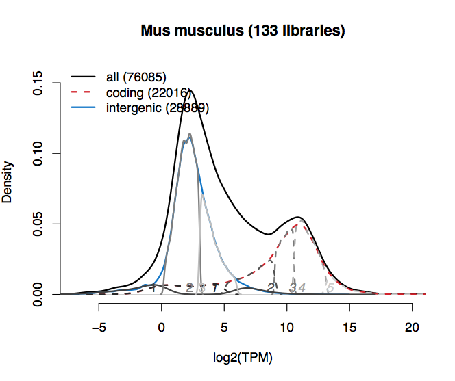

  - The species name is indicated in the title, along with the number of libraries summed
  - The black curve gives the distribution of summed TPM signal for all regions (the numbers of regions are in the legend)
  - The red dashed curve gives the distribution of summed TPM signal for all coding regions
  - The blue curve gives the distribution of summed TPM signal for all intergenic regions
  - The grey dashed curves are the deconvoluted coding gaussians, and the numbers in italics give their identification number
  - The grey plain curves are the deconvoluted intergenic gaussians, and the numbers (not in italics) give their identification number
  - The gaussians identification numbers can be a bit tricky to visualize. They are located at the peak of max density of the corresponding gaussian
  - In this density plots, the gaussians do not always look like gaussians, because what we are seeing here is the *a posteriori* attribution of regions to deconvoluted gaussians. For example if two overlapping gaussians were deconvoluted, one broad and one sharp in the middle of the broad one, the regions in the middle will all be attributed to the sharp gaussians, and the remaining regions on both sides will be attributed to the broad gaussian.
- The rationale to select intergenic gaussians is to keep “real” intergenic that are never seen highly expressed. These gaussians are the left-most on the density plots. We want to eliminate false intergenic regions, that are seen expressed in some samples (right-most gaussians).
- Example 1: mouse data in Bgee v14 (above plot)
  - In this example, we decide to remove the gaussian 3 (light gray) and the right part of the broad gaussian 1 (dark gray), because they overlap a lot with coding regions.
  - We set `numberGaussiansIntergenic` to 3: `mclust` deconvoluted 3 intergenic regions
  - We set `selectionSideIntergenic` to `Left` (default): the selected gaussian will delinate the maximum intergenic expression value (i.e., whole gaussian will be on the left of the maximum value)
  - We set `selectedGaussianIntergenic` to 2, to get a maximum log2(TPM) value of intergenic regions of ~3
  - The exact row in the `generated_files/RNA_Seq/gaussian_choice_by_species.txt` file will be: `10090\tMus musculus\t5\t3\tNA\tNA\t2\tLeft\t"Removed right-most intergenic gaussian (3 and right part of 1), because proportion of coding expressed was a little bit too low if only right part of gaussian 1 was removed"\tJR`

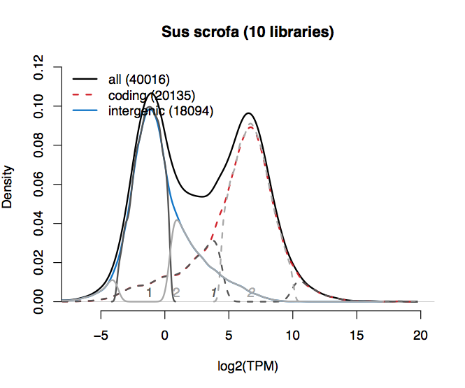

- Example 2: pig in Bgee v14
  - In this example, there are only 10 libraries summed, this is not a lot
  - We decide to remove right-most part of broad gaussian 2 because it overlaps a lot with coding regions
  - The exact row in the `generated_files/RNA_Seq/gaussian_choice_by_species.txt` file will be: `9823\tSus scrofa\t2\t2\tNA\tNA\t1\tLeft\t"Removed right-most intergenic gaussian (2)"\tJR`

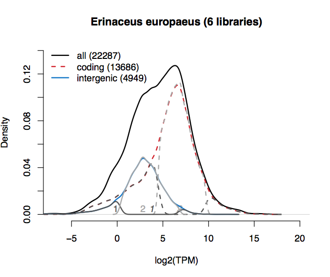

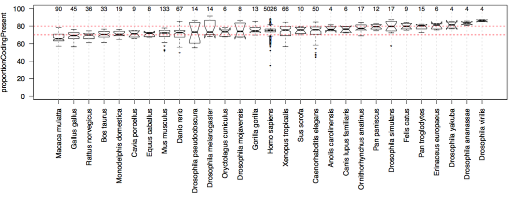

Boxplot

- - If with your choice of gaussians the % of coding genes expressed is quite similar to other species, keep this choice. If it stands out, make a different choice of gaussian, document it in the `comment` field, rerun the 1Run/rna_seq_presence_absence.R script and see if the % of coding genes is now more similar to other species. If the % of coding genes expressed was too high, probably you eliminated too many intergenic gaussians, and conversely if it was too low, you should probably eliminate more intergenic gaussians. We try to target a % coding present between 70 and 80%. As you can see in the above boxplot it is not easy to get this for each species, maybe because of the quality of the datasets, the low number of samples summed for some species, or the origin of the samples (e.g., of all samples from one species come from a tissue expressing very few genes).
  - In the above example 1 we went through this procedure (keeping gaussian 3 at first, then removing it) to adjust the choice of gaussians at best
  - Between different choices that are giving equally good results, keep the choice that gives the lowest variance in % of coding genes expressed across samples2
  - For some species, maybe because of low quality of data, or low number of samples, it is difficult to find a good choice. In this case, take the less worse choice… This is the case for example for *Erinaceus europaeus* in example 3 above, where intergenic regions have almost the same distribution of signal as protein coding regions!
  - This procedure might seem like cheating, but the rationale for the success of our method is that the % of coding expressed is quite similar across samples from the same species (low variance), not that it is directly comparable across species.
  - In some cases, it is possible that the density plot in PDF is not clear enough and lead to wrong choice of gaussians. After running the 1Run/rna_seq_presence_absence.R script, you can check the TPM threshold used for each individual library, and the maximum summed TPM expression of the intergenic regions selected for a given species. This can help detect strange things happening.
- After choosing all gaussians and when the `gaussian_choice_by_species.txt` file is ready, launch `make presence_absence` to run the 1Run/rna_seq_presence_absence.R script to call presence/absence for each library and generate summary boxplots.
  - Results are written in `$(RNASEQ_CLUSTER_PRESENCE_RES)` folder, for example `presence_absence_bgee_v14`.
  - This script takes ~1 day to complete
  - It creates one subfolder per sample, with 4 files: `abundance_gene_level+fpkm+intergenic+calls.tsv`, `cutoff_info_file.tsv`, `abundance_gene_level+new_tpm+new_fpkm+calls.tsv`, and `distribution_TPM_genic_intergenic+cutoff.pdf`
  - NOTE: the script can be run to produce the final boxplots only (the .RDa file needs to be present in the output folder already). Set `plot_only` option to TRUE.
  - Check success of script with the following commands. You should get the number of samples mapped, minus the number of samples excluded.

  ```
  ll presence_absence_bgee_v14_v4/*/abundance_gene_level+fpkm+intergenic+calls.tsv | wc
  ll presence_absence_bgee_v14_v4/*/abundance_gene_level+new_tpm+new_fpkm+calls.tsv | wc
  ll presence_absence_bgee_v14_v4/*/cutoff_info_file.tsv | wc
  ll presence_absence_bgee_v14_v4/*/distribution_TPM_genic_intergenic+cutoff.pdf | wc
  ```

- Copy files of `$(RNASEQ_CLUSTER_PRESENCE_RES)` subfolders (1 per sample) to subfolders of `$RNASEQ_CLUSTER_ALL_RES`

```
cd $(RNASEQ_CLUSTER_PRESENCE_RES)
for folder in *; do echo $folder; /bin/cp $folder/* $(RNASEQ_CLUSTER_ALL_RES)/$folder/; done
## /bin/cp used because cp is an alias to cp -i
```

NOTE: `$(RNASEQ_CLUSTER_PRESENCE_RES)` could possibly be set to `$(RNASEQ_CLUSTER_ALL_RES)` and the presence calls files be written directly in the subfolders with the mapping results. I considered it safer to generate in a separate folder and then copy.

- Back-up results and send useful files to `devbioinfo` server: `make save_and_send_results_back`

## RNA-Seq insertion

- Before insertion, list all unique strains present in our annotations, to merge inconsistent strains, e.g., ‘Wild Type’ or ‘wild type’ instead of ‘wild-type’ (see, e.g., https://gitlab.isb-sib.ch/Bgee/bgee_pipeline/issues/67#note_4654)
- See pipeline/Affymetrix/README.md for a list of useful grep commands allowing to catch inconsistencies in wildly used strain names.
- `make insert_RNA_seq`
  - Warning messages are expected, because some commented libraries have incomplete annotation. Please verify if the library is indeed commented (`Commented: 1`). For example:

  ```
  Warning: no platform specified for [GSE57338--GSM1379831]. Commented: 1
  Warning: no stageId specified for [SRP009247--SRX105065]. Commented: 1
  Warning: no uberonId specified for [SRP009247--SRX105066]. Commented: 1
  ```

  - Check carefully the statistics and strains inserted, in file `insert_RNA_seq`
  - **TODO**? At the beginning of the script, we check if each library has indeed a non empty file with results. This doesn’t prevent truncated files to be considered, should we add more sophisticated checks (when reading the actual files)?
  - At the beginning of log messages in standard output file, the number of libraries to insert is indicated. It is different than the number of annotated libraries
    - Some libraries are annotated but commented out
    - Some libraries are from species not inserted in Bgee
    - Some libraries are excluded because not from RNA-Seq (CAGE-Seq, miRNA-Seq, etc)
    - Some libraries are excluded because not found in SRA
    - Some libraries are excluded from WormBase annotation file
    - The difference: number annotated libraries - all reasons above should give the number of libraries in `generated_files/RNA_Seq/rna_seq_sample_info.txt` file
    - In addition some libraries are excluded after mapping, usually because of low quality mapping
    - This gives the final number of libraries to be inserted for the Bgee release (5745 for Bgee v14)
  - The script can be run in `-debug` mode. At the end of the script, the number of rows expected in the `rnaSeqResult` table is given (and number excluded rows as well).
  - Once everything is good, we can launch the insertion in expression table.
- `make check_conditions`
  - It will check validity of inserted conditions: before running `insert_expression`, you should generate the file `check_conditions`, to detect invalid conditions not supposed to exist in the related species. See ‘Details’ section of pipeline/post_processing/README.md for an explanation on how to fix such issues (in case the annotations were not incorrect).
- `make insert_expression`
  - Check carefully statistics in file `insert_expression`
  - **TODO**? This would be a place to look for low quality samples (low % genic present?) and flag them (give low quality to all their calls?). Not clear which criteria and thresholds are the most relevant to flag the low-quality samples though…
  - **TODO**? Combine 3Insertion/insert_rna_seq.pl and 3Insertion/insert_rna_seq_expression.pl, similarly to Affymetrix data insertion?
  - Note: table `rnaSeqTranscriptResult` is in the database but not filled. It could potentially store transcript-level results that Kallisto originally produced

## Insert feature length

- `make export_length` to be run on Vital-IT
- Add length info file to GIT project (generated_files/RNA_Seq/ folder)
- `make insert_feature_length` to be run on our server
- Check the `transcript` table in database to check for good insertion
- Effective length refers to the number of possible start sites a feature could have generated a fragment of that particular length. It is lower than transcript size. We do not insert it because it is not in the Kallisto output files. Indeed, the effective length is used to incorporate the bias correction in Kallisto, so it differs from library to library within the same species.
- Note: Ensembl transcript IDs are not unique (same ones for chimp and bonobo for example). `bgeeTranscriptId` is unique though

## Calculation of TMM normalization factors

- We inserted TPMs and FPKMs recalculated based on genic regions only, so we calculate TMM factors using the read counts on genic regions only.
- 3Insertion/calculate_TMM_factors.R: inspired from pipeline/Differential_expression/diff_analysis_rna_seq.R (function `calcNormFactors`). This script calculates the TMM factors using the Bioconductor package edgeR, for a set of samples listed in a ‘.target’ file (typically, all samples of an experiment, within one species, platform, library type and library orientation). The output is identical to the ‘.target’ file, with one column appended that includes the TMM factors for all samples.
  - This script is launched by the perl script 3Insertion/launch_calculate_TMM_factors.pl.
- 3Insertion/launch_calculate_TMM_factors.pl: inspired from pipeline/Differential_expression/launch_diff_analysis_rna_seq.pl to launch the calculation of TMM normalization factors.
  - This script is launched by the Makefile step `launch_calculate_TMM_factors`.
  - This script queries the Bgee database, so it must be launched after 3Insertion/insert_rna_seq.pl.
  - If only 1 sample is available for an experiment/species/platform/library type/library orientation, the TMM factor is set to 1. The ‘.target’ file is not created and 3Insertion/calculate_TMM_factors.R is not launched
  - This script can be launched for one experiment only. For example, for GSE30352:

  ```
  cd bgee_pipeline/pipeline/RNA_Seq/3Insertion
  PIPELINEROOT="../"
  BGEECMD="user=bgee__pass=bgee__host=127.0.0.1__port=3306__name=bgee_v14"
  RNASEQALLRES="/var/bgee/bgee/extra/pipeline/rna_seq/all_results/"
  RNASEQTMMTARG="/var/bgee/bgee/extra/pipeline/rna_seq/bioconductor/targets_TMM_bgee_v14"
  RNASEQTMMPATH="/var/bgee/bgee/extra/pipeline/rna_seq/processed_TMM_bgee_v14/"
  perl launch_calculate_TMM_factors.pl -bgee=$BGEECMD -path_generes=$RNASEQALLRES -path_target=$RNASEQTMMTARG -path_processed=$RNASEQTMMPATH GSE30352
  ```

  - When whole pipeline was run once, it is a good idea to check the amplitude and distribution of TMM values across all experiments. Do we get aberrant values? For Bgee v14, values range from 0.096838 (in SRP012682 experiment / GTEx) to 2.695775 (in SRP000401 experiment). These are totally reasonable values
- Check step in Makefile: `make check_TMM_factors`.
  - **TODO**? Add a check to see if each inserted library got a TMM factor generated
- Insertion step in Makefile: `make insert_TMM_factors`
- **TODO**? Should we store in the database the groups of libraries that were used to calculate the TMM factors. This info is only available in ‘.target’ files for now
- **TODO**? It would also be interesting to store the TMM factors used to do the differential expression analyses (there should not be one for each library in this case…)

## BACK-UP

- There are diverse steps in the Makefile
- **TODO** we need a final back-up stage, where we backup all the processed files on our server. For now this is not in the Makefile

## Partial update of Bgee to add RNA-Seq data only

```
author dataSource dataSourceToSpecies keyword taxon species speciesToSex speciesToKeyword CIOStatement
evidenceOntology stage stageTaxonConstraint stageNameSynonym stageXRef anatEntity anatEntityTaxonConstraint
anatEntityXRef anatEntityNameSynonym anatEntityRelation anatEntityRelationTaxonConstraint
summarySimilarityAnnotation similarityAnnotationToAnatEntityId rawSimilarityAnnotation OMAHierarchicalGroup
geneOntologyTerm geneOntologyTermAltId geneOntologyRelation geneBioType gene geneToOma geneNameSynonym geneXRef
transcript cond estLibrary estLibraryToKeyword expressedSequenceTag
estLibraryExpression microarrayExperiment microarrayExperimentToKeyword chipType affymetrixChip affymetrixProbeset
microarrayExperimentExpression inSituExperiment inSituExperimentToKeyword inSituEvidence inSituSpot
inSituExperimentExpression rnaSeqExperiment rnaSeqExperimentToKeyword rnaSeqPlatform rnaSeqLibrary rnaSeqRun
rnaSeqLibraryDiscarded rnaSeqResult rnaSeqTranscriptResult expression downloadFile speciesDataGroup speciesToDataGroup
```

- To update only RNA-Seq data for Bgee 14.1, following tables were **NOT** dumped from Bgee 14.0: (4 tables not dumped over 74 tables in total)

```
globalCond
globalCondToCond
rnaSeqExperimentExpression
globalExpression
```

- Following tables were not dumped because unused for now: (7 tables not dumped over 74 tables in total)

```
differentialExpressionAnalysis
deaSampleGroup
deaSampleGroupToAffymetrixChip
deaSampleGroupToRnaSeqLibrary
deaAffymetrixProbesetSummary
deaRNASeqSummary
differentialExpression
```

- Remove some runs/libraries/experiments if needed
  - To remove runs:
    - remove lines from rnaSeqRun with matching rnaSeqRunId
    - search for libraries with no remaining runs and remove them, e.g., `SELECT t1.* FROM rnaSeqLibrary AS t1 LEFT OUTER JOIN rnaSeqRun AS t2 ON t1.rnaSeqLibraryId = t2.rnaSeqLibraryId WHERE t2.rnaSeqLibraryId IS NULL;`
    - search for experiments with no remaining libraries and delete them (see below)
  - To remove libraries:
    - remove lines from `rnaSeqResult` with matching rnaSeqLibraryId
    - remove lines from `rnaSeqLibrary` with matching rnaSeqLibraryId
    - Search for experiments with no remaining libraries and delete them, e.g. `SELECT t1.* FROM rnaSeqExperiment AS t1 LEFT OUTER JOIN rnaSeqLibrary AS t2 ON t1.rnaSeqExperimentId = t2.rnaSeqExperimentId WHERE t2.rnaSeqExperimentId IS NULL;`
    - Add the rnaSeqLibraryIds to the table rnaSeqLibraryDiscarded
- Do NOT dump the table `rnaSeqExperimentExpression`
- clean table `cond` and `expression` to remove lines related only to RNA-Seq data
  - reset `expressionId` field in `rnaSeqResult` table, i.e., `UPDATE rnaSeqResult SET expressionId = NULL;`
  - Note that the table `rnaSeqExperimentExpression` should NOT have been dumped
  - delete lines in table `expression` that are not used anymore (i.e., that were used only for RNA-Seq data), i.e., from Bgee 14.0 tables: `DELETE t1 FROM expression AS t1 LEFT OUTER JOIN expressedSequenceTag AS t2 ON t1.expressionId = t2.expressionId LEFT OUTER JOIN estLibraryExpression AS t3 ON t1.expressionId = t3.expressionId LEFT OUTER JOIN affymetrixProbeset AS t4 ON t1.expressionId = t4.expressionId LEFT OUTER JOIN microarrayExperimentExpression AS t5 ON t1.expressionId = t5.expressionId LEFT OUTER JOIN inSituSpot AS t6 ON t1.expressionId = t6.expressionId LEFT OUTER JOIN inSituExperimentExpression AS t7 ON t1.expressionId = t7.expressionId LEFT OUTER JOIN rnaSeqResult AS t8 ON t1.expressionId = t8.expressionId LEFT OUTER JOIN rnaSeqExperimentExpression AS t9 ON t1.expressionId = t9.expressionId WHERE t2.expressionId IS NULL AND t3.expressionId IS NULL AND t4.expressionId IS NULL AND t5.expressionId IS NULL AND t6.expressionId IS NULL AND t7.expressionId IS NULL AND t8.expressionId IS NULL AND t9.expressionId IS NULL;`
  - remove cond not used anywhere, see ../annotations/README.md#deletion-of-unused-conditions.
- Insert the new RNA-Seq data for the partial update; this should also reinsert the necessary lines in `expression` and `cond` tables.
- relaunch insertion in `globalExpression` and `globalCond`
- relaunch rank generation
- check basically all post-processing steps
- update values in table `downloadFile`

### Steps done for partial update 14.1

#### Removal of some RNA-Seq libraries/experiments

- For Bgee 14.1, as compared to Bgee 14.0, following runs were removed:

```
SRR069493
SRR069510
SRR069576
SRR069577
SRR069580
SRR070036
SRR085466
SRR085467
SRR089302
SRR089303
SRR089304
SRR089352
SRR089353
SRR089354
SRR089358
SRR089359
SRR089360
SRR089361
SRR089362
SRR089363
SRR1051537
SRR1051538
SRR1051539
SRR1051540
SRR1051541
SRR1051542
SRR1051543
SRR1051544
SRR1051545
SRR1051546
SRR1051547
SRR1051548
SRR1051549
SRR1051550
SRR1051551
SRR1051570
SRR1051571
SRR1051572
SRR1051573
SRR1051574
```

[output cut: 36 more lines]

```
SRR125482
SRR330557
SRR330558
SRR330559
SRR330560
SRR330565
SRR330566
SRR330567
SRR330568
SRR654754
SRR656758
SRR660066
SRR660957
SRR661361
SRR820938
```

- For Bgee 14.1, as compared to Bgee 14.0, following libraries were removed:

```
SRX007069
SRX007170
SRX007173
SRX035162
SRX036882
SRX036967
SRX036969
SRX036970
SRX047787
SRX091556
SRX091557
SRX091558
SRX091559
SRX091564
SRX091565
SRX091566
SRX091567
SRX221189
SRX221861
SRX222609
SRX222921
SRX223154
SRX261929
SRX393267
SRX393268
SRX393269
SRX393270
SRX393271
SRX393272
SRX393273
SRX393274
SRX393275
SRX393276
SRX393277
SRX393278
SRX393279
SRX393280
SRX393281
SRX393300
SRX393301
```

[output cut: 23 more lines]

```
SRX393366
SRX393367
SRX393368
SRX393369
SRX393370
SRX393392
SRX393393
SRX393394
SRX407339
SRX411093
SRX412945
SRX416615
SRX417198
SRX419414
SRX421312
```

- For Bgee 14.1, as compared to Bgee 14.0, following experiments were removed because no remaining libraries:

```
GSE53690
GSE57369
SRP001010
SRP009247
SRP015688
```

- Among the new experiments added for Bgee 14.1, the followings were discarded:

```
SRP041131 (single-cell protocol, proportion of protein coding genes detected as present too low)
```

- Among the new libraries added for Bgee 14.1, the followings were discarded. For all of them, the reason was: proportion of protein coding genes detected as present too low.

```
SRX1125042
SRX028802
SRX028803
SRX028810
SRX028812
SRX028813
SRX028908
SRX028909
SRX028910
SRX494044
ERX016327
ERX016345
SRX737153
SRX037197
SRX050630
SRX099901
```

- 3 more conditions are not used anywhere, because they were remapped for insertion in the `expression` table:

```
+-------------+-----------------------+----------------+----------------+-----------+-----+-------------+--------+
| conditionId | exprMappedConditionId | anatEntityId   | stageId        | speciesId | sex | sexInferred | strain |
+-------------+-----------------------+----------------+----------------+-----------+-----+-------------+--------+
|         650 |                   649 | CL:2000001     | UBERON:0000113 |      9544 | NA  |           0 | NA     |
|         652 |                   651 | CL:0000492     | UBERON:0000113 |      9544 | NA  |           0 | NA     |
|         654 |                   653 | UBERON:0001052 | UBERON:0000113 |      9544 | NA  |           0 | NA     |
+-------------+-----------------------+----------------+----------------+-----------+-----+-------------+--------+
```

They were remapped to:

```
+-------------+-----------------------+----------------+----------------+-----------+---------------+-------------+-----------+
| conditionId | exprMappedConditionId | anatEntityId   | stageId        | speciesId | sex           | sexInferred | strain    |
+-------------+-----------------------+----------------+----------------+-----------+---------------+-------------+-----------+
|         649 |                   649 | CL:2000001     | UBERON:0000113 |      9544 | not annotated |           0 | wild-type |
|         651 |                   651 | CL:0000492     | UBERON:0000113 |      9544 | not annotated |           0 | wild-type |
|         653 |                   653 | UBERON:0001052 | UBERON:0000113 |      9544 | not annotated |           0 | wild-type |
+-------------+-----------------------+----------------+----------------+-----------+---------------+-------------+-----------+
```

- number of rows in `rnaSeqResult` went from 327,090,880 to 324,297,865 (2,793,015 rows deleted)
- number of rows in `rnaSeqLibrary` went from 5,745 to 5,667 (78 rows deleted)
- number of rows in `rnaSeqExperiment` went from 41 to 36 (5 rows deleted)

#### Clean table `cond` and `expression` to remove lines related only to RNA-Seq data

- number of rows in `expression` went from 94,981,552 to 50,486,926 (44,494,626 rows deleted)
- number of rows in `cond` table went from 39,317 to 38,793 (524 rows deleted). Of note, some conditions were unused in bgee_v14 (511 conditions), it is unclear why. The 524 rows deleted also include these 511 conditions.
- number of conditions not used anywhere went from 511 to 524 (13 more conditions unused, including the 3 from the previous step)
- Of note, many conditions used in the annotations of RNA-Seq libraries (inserted in table `rnaSeqLibrary`) are remapped to a different condition for insertion in the `expression` table:
  - Of the 991 conditions used in the table `rnaSeqLibrary` after discarding some libraries, 856 are remapped to another condition.